# Data report - Gapminder dataset

Author

Saar Alon-Barkat

Published

May 1, 2025

In this session, we will practice some data exploration.

Technically, we will learn the following verbs (functions) from `dplyr` package (from `tidyverse` metapackage):

- `filter`
- `glimpse`
- `select`
- `arrange`
- `summary`
- `count`
- `group_by` & `summarise`

Also, we will learn to visualize data and create several basic plots, via `ggplot` package (from `tidyverse` metapackage).

- Bar plot (`geom_bar`)
- Histogram (`geom_histogram`)
- Box-plot (`geom_boxplot`)
- Scatter plot (`geom_point`)

We will explore the `gapminder` dataset, which includes real-world country-level panel data (1952-2007) for:

- Life expectancy (`lifeExp`)
- Population size (`pop`)
- GDP percapita (`gdpPercap`)

The dataset is available from `gapminder` `r` package. For more information on gapminder see: https://www.gapminder.org/

First, we need to call/open the `tidyverse` and `gapminder` libraries

```r
library(tidyverse)
library(gapminder)
```

Once we called these packages, we can use the tidyverse functions and the gapminer dataset. Let’s try to see if it works -

```r
gapminder %>%
  head()
```

```
# A tibble: 6 × 6
  country     continent  year lifeExp      pop gdpPercap
  <fct>       <fct>     <int>   <dbl>    <int>     <dbl>
1 Afghanistan Asia       1952    28.8  8425333      779.
2 Afghanistan Asia       1957    30.3  9240934      821.
3 Afghanistan Asia       1962    32.0 10267083      853.
4 Afghanistan Asia       1967    34.0 11537966      836.
5 Afghanistan Asia       1972    36.1 13079460      740.
6 Afghanistan Asia       1977    38.4 14880372      786.
```

Let’s save the gapminder as a dataframe in the working environment. Assign the name gapminder.

```r
gapminder <- gapminder

# alternatively, you can import the data from the csv file in the shared dropbox
# gapminder <- read_csv("data/gapminder.csv")
```

Let’s have a first look at the dataset, using the `glimpse` function. This is highly recommended anytime you import a new dataset.

```r
gapminder %>%
  glimpse()
```

```
Rows: 1,704
Columns: 6
$ country   <fct> "Afghanistan", "Afghanistan", "Afghanistan", "Afghanistan", …
$ continent <fct> Asia, Asia, Asia, Asia, Asia, Asia, Asia, Asia, Asia, Asia, …
$ year      <int> 1952, 1957, 1962, 1967, 1972, 1977, 1982, 1987, 1992, 1997, …
$ lifeExp   <dbl> 28.801, 30.332, 31.997, 34.020, 36.088, 38.438, 39.854, 40.8…
$ pop       <int> 8425333, 9240934, 10267083, 11537966, 13079460, 14880372, 12…
$ gdpPercap <dbl> 779.4453, 820.8530, 853.1007, 836.1971, 739.9811, 786.1134, …
```

We will create a subset of the data, only data from 2007. We will use `filter`. Assign the name `gapminder_2007`.

```r
gapminder_2007 <- gapminder %>%
  filter(year==2007)
```

# 1. Exploring a quantiative numeric variable (ratio)

Life expectancy is an example (`lifeExp`). Let’s have a look at this variable. Let’s use `select` function

```r
gapminder_2007 %>%
  select(country,
         lifeExp)
```

```
# A tibble: 142 × 2
   country     lifeExp
   <fct>         <dbl>
 1 Afghanistan    43.8
 2 Albania        76.4
 3 Algeria        72.3
 4 Angola         42.7
 5 Argentina      75.3
 6 Australia      81.2
 7 Austria        79.8
 8 Bahrain        75.6
 9 Bangladesh     64.1
10 Belgium        79.4
# ℹ 132 more rows
```

Because these are numeric values, we can sort the data based on this variable. Let’s use `arrange` function.

```r
gapminder_2007 %>%
  select(country,
         lifeExp) %>%
  arrange(lifeExp)
```

```
# A tibble: 142 × 2
   country                  lifeExp
   <fct>                      <dbl>
 1 Swaziland                   39.6
 2 Mozambique                  42.1
 3 Zambia                      42.4
 4 Sierra Leone                42.6
 5 Lesotho                     42.6
 6 Angola                      42.7
 7 Zimbabwe                    43.5
 8 Afghanistan                 43.8
 9 Central African Republic    44.7
10 Liberia                     45.7
# ℹ 132 more rows
```

The default is ascending. Let’s switch to descending by adding `%>% desc()`

```r
gapminder_2007 %>%
  select(country,
         lifeExp) %>%
  arrange(lifeExp %>% desc())
```

```
# A tibble: 142 × 2
   country          lifeExp
   <fct>              <dbl>
 1 Japan               82.6
 2 Hong Kong, China    82.2
 3 Iceland             81.8
 4 Switzerland         81.7
 5 Australia           81.2
 6 Spain               80.9
 7 Sweden              80.9
 8 Israel              80.7
 9 France              80.7
10 Canada              80.7
# ℹ 132 more rows
```

We want to explore the distribution of this variable.

One way to do it, is by looking at measures, like mean, median and quartiles.

```r
gapminder_2007 %>%
select(lifeExp) %>%
summary()
```

```
    lifeExp
 Min.   :39.61
 1st Qu.:57.16
 Median :71.94
 Mean   :67.01
 3rd Qu.:76.41
 Max.   :82.60
```

One of the best ways to do this is to visualize. Below, we learn how to use ggplot for this.

Now, try yourself to explore another numeric variable - GDP per capita (`gdpPercap`). [Use copy, paste, and tweak]

Arrange countries from lowest to highest GDP per capita (use `arrange`):

Now, extract the key statistics (use `summary`)

# 2. Exploring a categorical variable

Now let’s have a look at a categorical variable: `continent`

What do you think happens if you add `arrange`?

```r
gapminder_2007 %>%
  select(country,
         continent) %>%
  arrange(continent)
```

```
# A tibble: 142 × 2
   country                  continent
   <fct>                    <fct>
 1 Algeria                  Africa
 2 Angola                   Africa
 3 Benin                    Africa
 4 Botswana                 Africa
 5 Burkina Faso             Africa
 6 Burundi                  Africa
 7 Cameroon                 Africa
 8 Central African Republic Africa
 9 Chad                     Africa
10 Comoros                  Africa
# ℹ 132 more rows
```

The only thing we can do to explore the distribution of categorical variables is to count them

```r
gapminder_2007 %>%
  count(continent) %>%
  arrange(n %>% desc())
```

```
# A tibble: 5 × 2
  continent     n
  <fct>     <int>
1 Africa       52
2 Asia         33
3 Europe       30
4 Americas     25
5 Oceania       2
```

# 3. Visualising variable distributions via `ggplot2`

## Categorical variable

To visualize the distribution of a categorical variable we will normally use barplot.

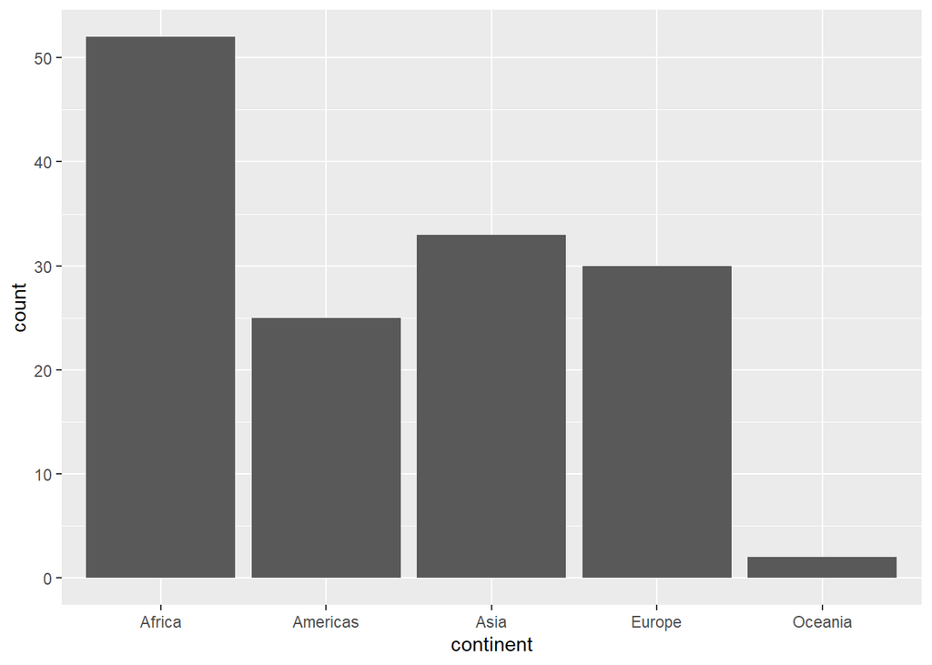

```r
gapminder_2007 %>%
  ggplot(mapping = aes(x = continent)) +
  geom_bar()
```

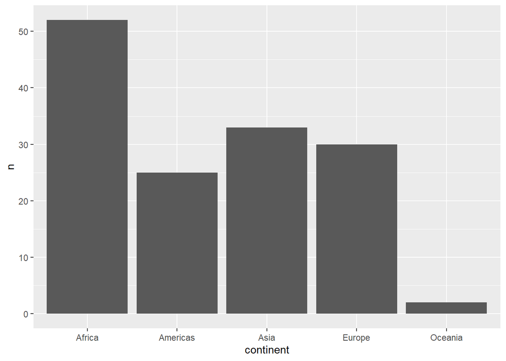

```r
# Alternatively, you can do this and get the same result:
gapminder_2007 %>%
  count(continent) %>%
  ggplot(mapping = aes(x = continent, y=n)) +
  geom_col()
```

## continuous variable

To visualize the distribution of a continuous variable we will normally use histogram or boxplot.

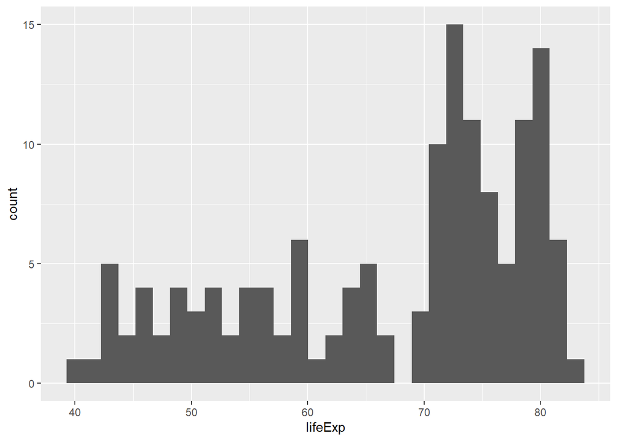

```r
gapminder_2007 %>%
  ggplot(mapping=aes(x = lifeExp)) + # Here we need to define the variables to be used
  geom_histogram() # now we need to define the type of plot (geometric dimension)
```

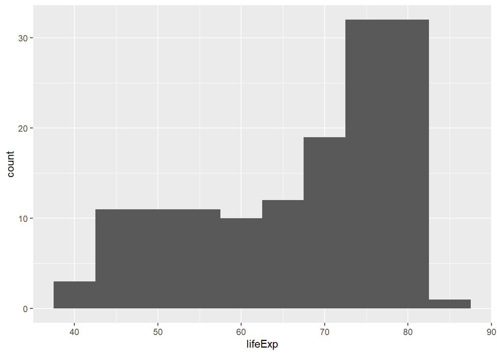

```r
gapminder_2007 %>%
ggplot(aes(lifeExp))+
  geom_histogram(binwidth = 5)
```

Can you imagine where are Q1,median, mean and Q3? A best way to visualize it is using a “boxplot”.

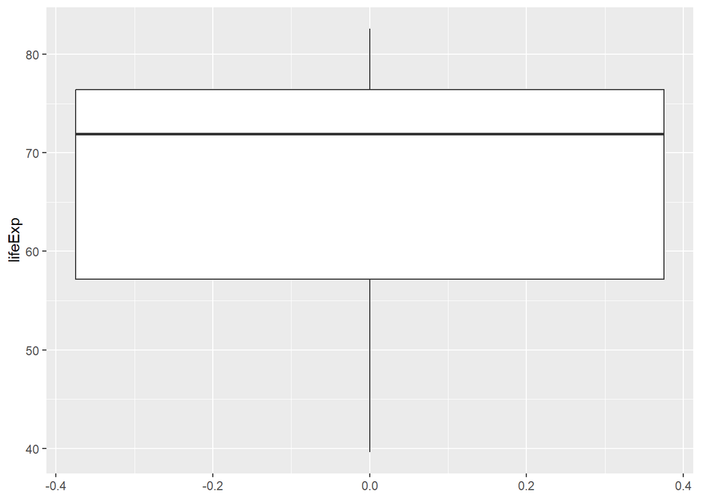

```r
gapminder_2007 %>%
  ggplot(mapping = aes(y = lifeExp)) +
  geom_boxplot()
```

Now, try to explore and visualize GDP per capita using histogram and boxplot (again, use copy, paste, and tweak)

# 4. Exploring the relations between two variables

The best way to explore the link between two variables is to visualize. Again, we will use different plots (`geom_`) depending on the type of the data.

## Relations between quantitative variable and categorical variable can be visualized via boxplot.

e.g. - let’s compare the levels of life expectancy across continents.

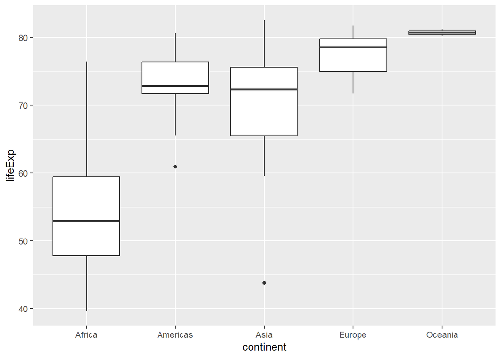

```r
gapminder_2007 %>%
  ggplot(mapping = aes(x = continent, y = lifeExp)) +
  geom_boxplot()
```

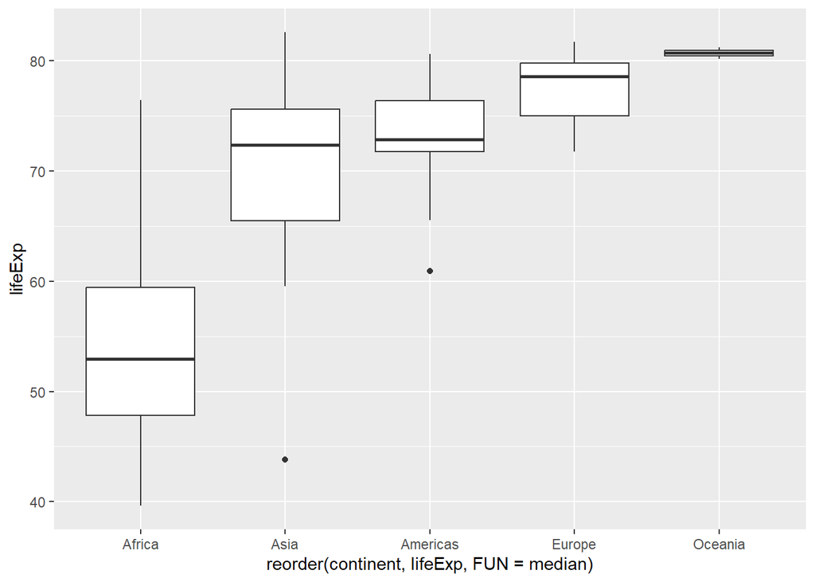

```r
# Tip: you can also sort categories
gapminder_2007 %>%
  ggplot(aes(x=reorder(continent,lifeExp, FUN = median),y=lifeExp))+
  geom_boxplot()
```

Very often, people use points or bars to compare a quantiative variable across groups. But boxplot is better because is can also show you differences in distributions.

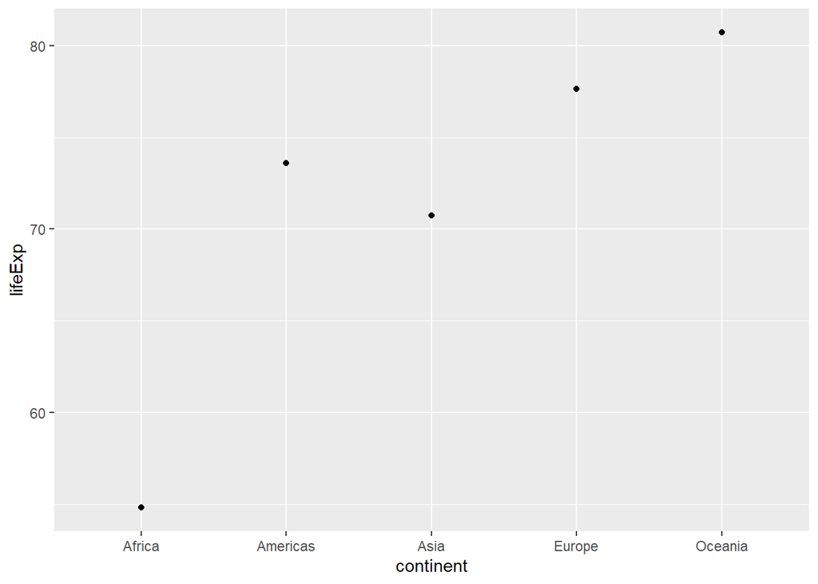

```r
gapminder_2007 %>%
  ggplot(mapping = aes(x = continent, y = lifeExp)) +
stat_summary(fun.y = "mean", geom = "point")
```

Or - use both:

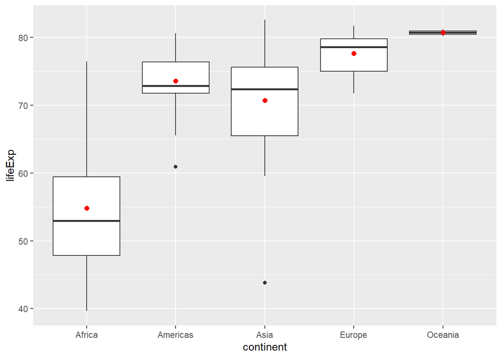

```r
gapminder_2007 %>%
  ggplot(mapping = aes(x = continent, y = lifeExp)) +
    geom_boxplot()+
stat_summary(fun.y = "mean", geom = "point",color="red",size=2)
```

If we want to extract the means and medians for each group - we can use `group_by` and `summarize`

```r
gapminder_2007 %>%
  group_by(continent) %>%
  summarise(mean_life_expectancy = lifeExp %>% mean(),
            median_life_expectancy = lifeExp %>% median())
```

```
# A tibble: 5 × 3
  continent mean_life_expectancy median_life_expectancy
  <fct>                    <dbl>                  <dbl>
1 Africa                    54.8                   52.9
2 Americas                  73.6                   72.9
3 Asia                      70.7                   72.4
4 Europe                    77.6                   78.6
5 Oceania                   80.7                   80.7
```

For self practice - try to do the same with GDP per capita (i.e. compare GDP across continents)

## Relations between two continuous variables

The best way to visualize the relation between two continuous variables is a scatterplot.

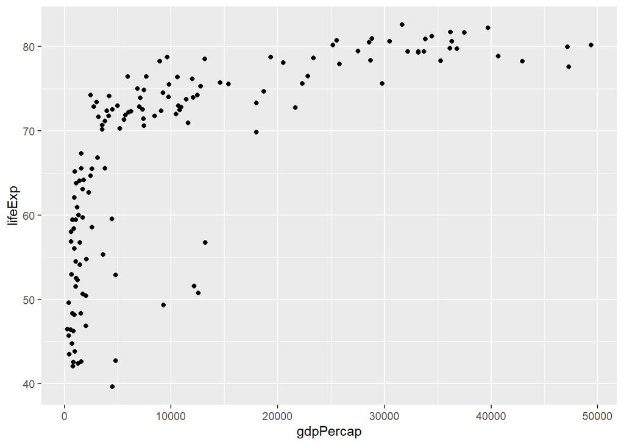

```r
gapminder_2007 %>%
  ggplot(aes(x = gdpPercap, y = lifeExp)) +
  geom_point()
```

We may want to add a trend/regression line

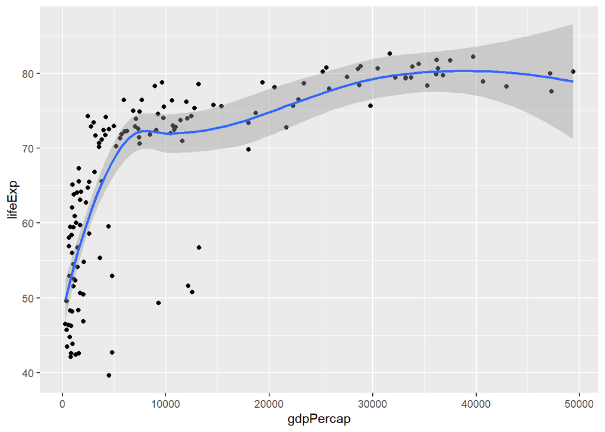

```r
gapminder_2007 %>%
  ggplot(aes(x = gdpPercap, y = lifeExp)) +
  geom_point()+
  geom_smooth()
```

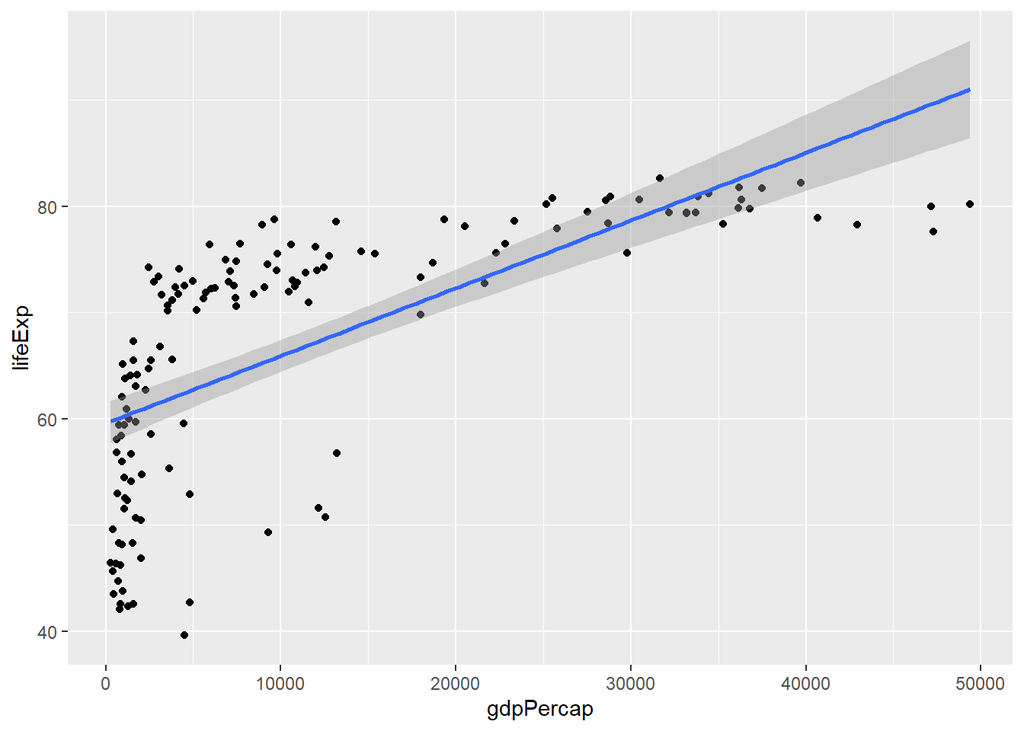

```r
#To change the default and use a linear trend/regression - add `method="lm"`
gapminder_2007 %>%
  ggplot(aes(x = gdpPercap, y = lifeExp)) +
  geom_point()+
  geom_smooth(method = "lm")
```

# 5. Adding more dimensions

Thus far, we explored the relations between two variables. But very often, we want to add more dimensions - e.g. exploring the relations across different groups/clusters or over time. This can be important to account for potential confounding variables, or to explore interactions.

Again - I would recommned exploring this by visualizing the data. There are several easy ways you can add more dimensions to the plot:

For categorical variables: - playing with colors and/or shapes. - Using “faceting”.

For continuous variables: - Playing with size.

Let’s see a few examples:

We want to explore the relations between well-being and life expectancy across continents. To do so we can use different colors for each continent:

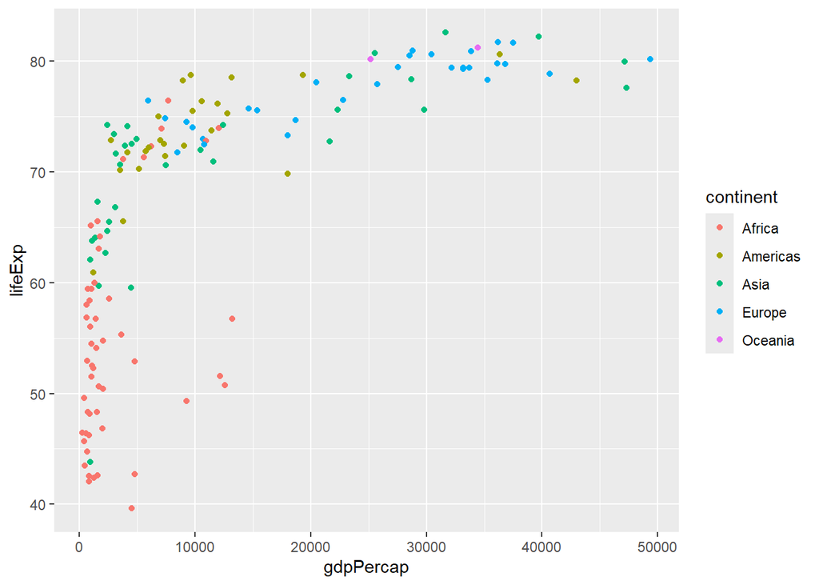

```r
gapminder_2007 %>%
  ggplot(aes(x = gdpPercap, y = lifeExp, color=continent)) +
# Try to replace color with `shape`
  geom_point()
```

Or use faceting (`facet_wrap`)

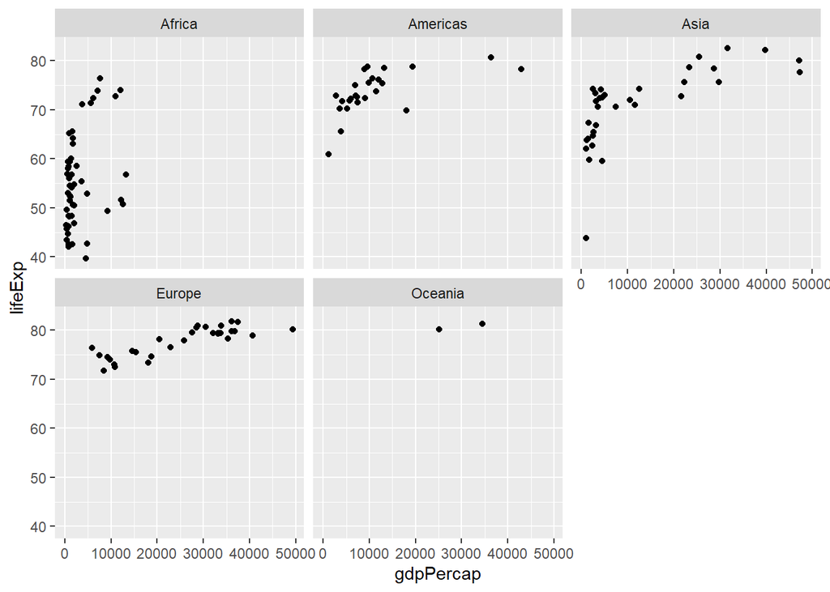

```r
gapminder_2007 %>%
  ggplot(aes(x = gdpPercap, y = lifeExp)) +
  geom_point()+
  facet_wrap(vars(continent))
```

Now, let’s add another continuous variable/dimension. Say we want to account for country population size, in addition. We can also play with the point size and shape. e.g. use size to represent population size.

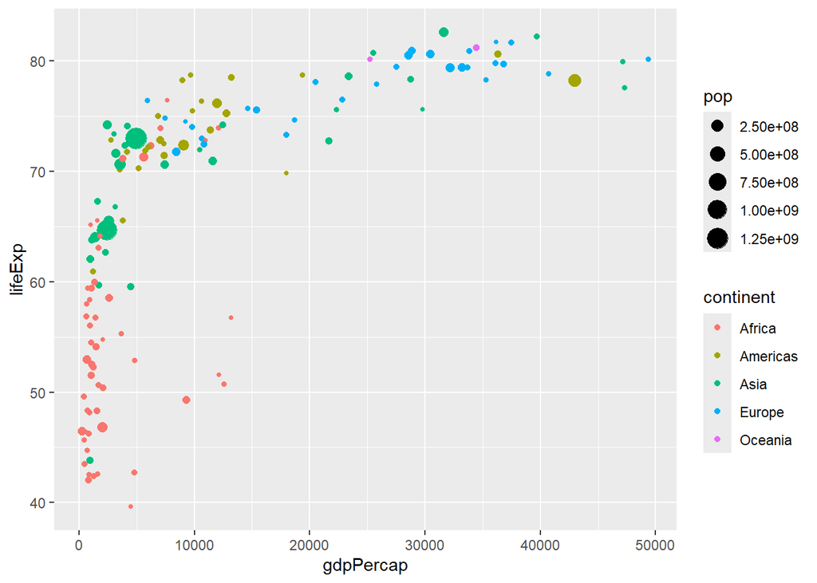

```r
gapminder_2007 %>%
  ggplot(aes(x = gdpPercap, y = lifeExp, color=continent, size = pop)) +
  geom_point()
```

And now, let’s add another categorical variable/dimension. Say we want to account for year, in addition. Let’s return to the full `gapminder` data for this, and use `facet_wrap`.

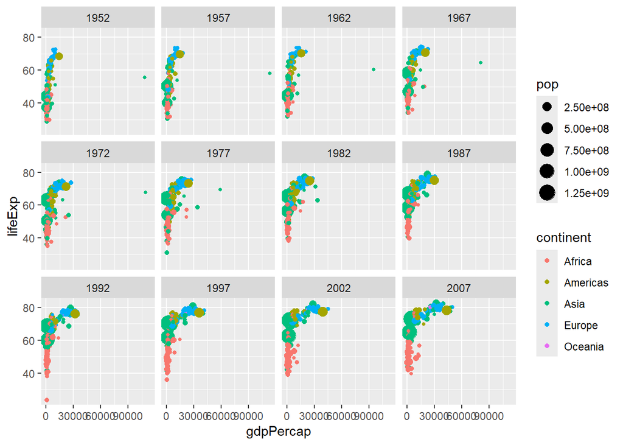

```r
gapminder %>%
  ggplot(aes(x = gdpPercap, y = lifeExp, color=continent, size = pop)) +
  geom_point() +
  facet_wrap(vars(year))
```

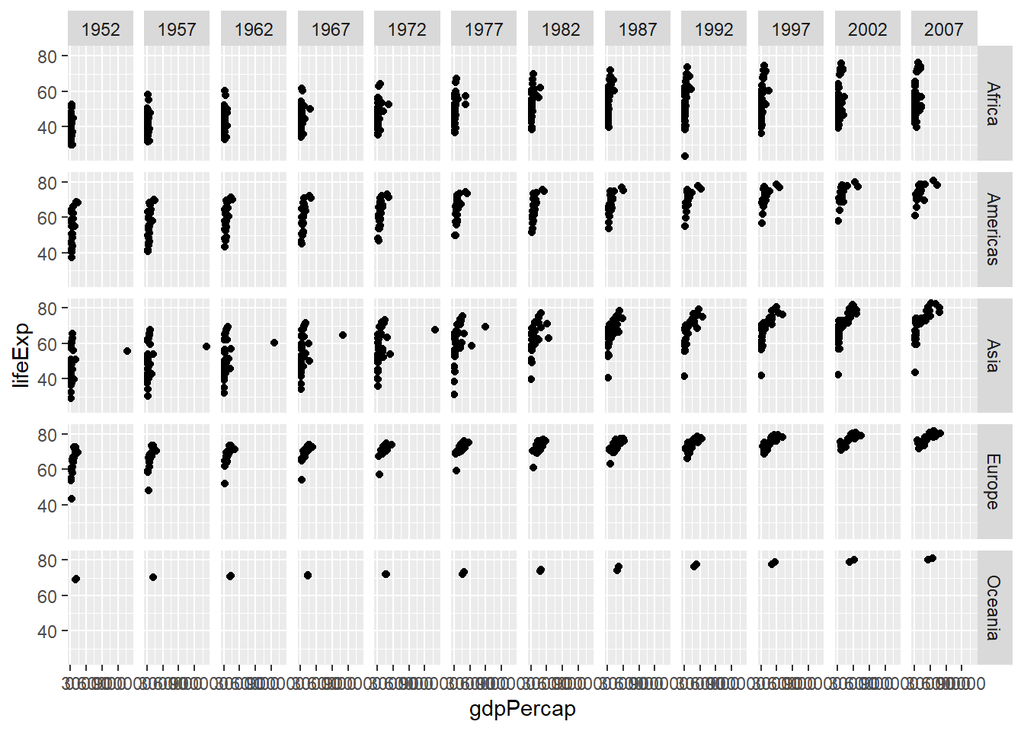

```r
gapminder %>%
  ggplot(aes(x = gdpPercap, y = lifeExp)) +
  geom_point() +
  facet_grid(continent~year)
```

# 6. Exploring a variable over time

To visualize a continuous variable over time, we will normally use a line plot.

Let’s use simple example - first we will create an aggregated table summarizing the total population in all countries together for each year. We will name this table `pop_sum`

```r
pop_sum <- gapminder %>%
  group_by(year) %>%
  summarise(pop=sum(pop))

pop_sum
```

```
# A tibble: 12 × 2
    year        pop
   <int>      <dbl>
 1  1952 2406957150
 2  1957 2664404580
 3  1962 2899782974
 4  1967 3217478384
 5  1972 3576977158
 6  1977 3930045807
 7  1982 4289436840
 8  1987 4691477418
 9  1992 5110710260
10  1997 5515204472
11  2002 5886977579
12  2007 6251013179
```

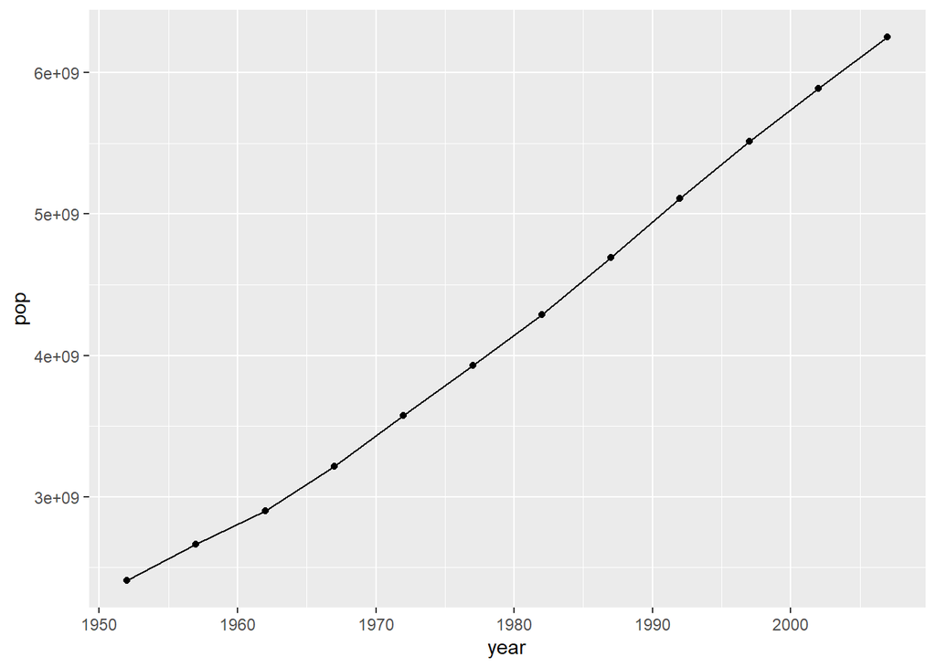

```r
pop_sum %>%
  ggplot(aes(x = year, y = pop)) +
  geom_point()+
  geom_line()
```

But - accounting for variation is always important. e.g. - life expectancy over time, accross countries.

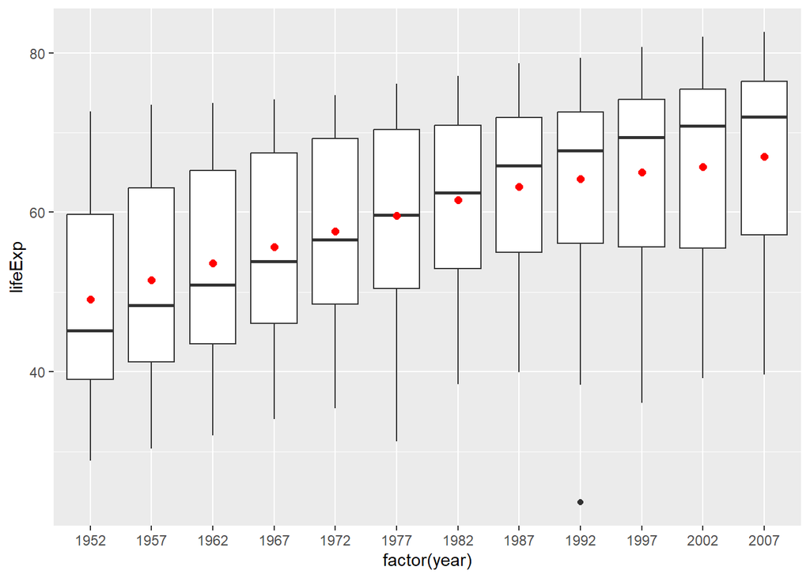

```r
gapminder %>%
  ggplot(mapping = aes(x = factor(year), y = lifeExp)) +
    geom_boxplot()+
stat_summary(fun.y = "mean", geom = "point",color="red",size=2)
```

For more inspiration for great (effective) visualizations in R check the R Graph Gallery: https://r-graph-gallery.com/

There are also plenty of R packages for data exploration solutions. Over time - you will find your favorites.